# Kruskal-Wallis Rank Sum Test in R

[Nathaniel E. Helwig](http://stat.umn.edu/~helwig) Department of Psychology & School of Statistics University of Minnesota

Copyright © February 17, 2026

# 1 $k \geq 3$ Independent Samples Location Problem

## 1.1 Overview

For the $k$ independent samples location problem, we have $N = \sum_{j=1}^k n_j$ observations

- $X_{ij}$ are iid from $F_j$ for $i = 1,\ldots,n_j$ and $j = 1,\ldots,k$
- $n_j$ is the number of observations from $F_j$

Note that the observations are independent within and between groups.

## 1.2 Location-Shift Model

The *location-shift* model assumes that

- $F_j(z - \theta - \tau_j) = F_0(z)$ where $\tau_j$ is the $j$-th group’s treatment effect
- $X_{ij} = \theta + \tau_j + \epsilon_{ij}$ where the $\epsilon_{ij}$ are iid with mean zero

## 1.3 Null and Alternative Hypotheses

The null hypothesis assumes that all groups have the same mean
$$H_{0}: \tau_1 = \tau_2 = \cdots = \tau_k$$
and we only have one reasonable alternative:
$$H_{1}: \tau_j \neq \tau_{j'} \ \mbox{for some} \ j,j'$$

# 2 Methodological Details

## 2.1 Kruskal-Wallis Statistic

Let $r_{ij}$ denote the rank of $X_{ij}$ in the combined sample of size $N$ observations.

Defining the sum and average of the combined ranks for each group
$$R_{j}= \sum_{i=1}^{n_{j}}r_{ij} \qquad \mbox{and} \qquad
\bar{R}_j=R_{j}/n_{j}$$
the Kruskal-Wallis test statistic $H$ is defined as
$$H = \frac{12}{N(N+1)}\sum_{j=1}^{k} n_{j}\left(\bar{R}_j -
\frac{N+1}{2}\right)^{2}$$
where $\frac{N+1}{2}=(\sum_{j=1}^{k}\sum_{i=1}^{n_{j}}r_{ij}/N)$ is the average of the rankings.

## 2.2 Null Distribution

Under $H_0$ all $M = \frac{N!}{\prod_{j=1}^k n_j!}$ arrangements of
$$\{n_1 \mbox{ in group } 1, \ n_2 \mbox{ in group } 2, \ \ldots, \ n_k
\mbox{ in group } k \}$$
occur with equal probability.

Note that $M = \frac{N!}{\prod_{j=1}^k n_j!}$ is the *multinomial coefficient*, which gives the number of ways $N$ objects can be placed into $k$ groups of specific sizes $(n_1,n_2,\ldots,n_k)$.

- Given $(n_1,n_2,\ldots,n_k)$, calculate $H$ for all $M$ possible outcomes
- Each outcome has probability $1/ M$ under $H_0$

Suppose we have sample sizes of $n_1 = 2$, $n_2 = 1$, and $n_3 = 1$.

There are $\frac{4!}{2!} = 12$ possible configurations of the ranks with group labels

| $\{R_1\}$ | $\{R_2\}$ | $\{R_3\}$ | $H$ statistic | Probability under $H_{0}$ |
| --- | --- | --- | --- | --- |
| 1,2 | 3 | 4 | 2.7 | $1/12$ |
| 1,2 | 4 | 3 | 2.7 | $1/12$ |
| 1,3 | 2 | 4 | 1.8 | $1/12$ |
| 1,3 | 4 | 2 | 1.8 | $1/12$ |
| 1,4 | 2 | 3 | 0.3 | $1/12$ |
| 1,4 | 3 | 2 | 0.3 | $1/12$ |
| 2,3 | 1 | 4 | 2.7 | $1/12$ |
| 2,3 | 4 | 1 | 2.7 | $1/12$ |
| 2,4 | 1 | 3 | 1.8 | $1/12$ |
| 2,4 | 3 | 1 | 1.8 | $1/12$ |
| 3,4 | 1 | 2 | 2.7 | $1/12$ |
| 3,4 | 2 | 1 | 2.7 | $1/12$ |

Note: $\{R_j\}$ denotes the set of ranks $\{r_{1j}, \ldots, r_{n_jj}\}$

## 2.3 Statistical Inference

### 2.3.1 Exact Test

One-Sided Test (Greater Than)

- $H_{0}: \tau_1 = \tau_2 = \cdots = \tau_k$ versus $H_{1}: \tau_j \neq \tau_{j'} \ \mbox{for some} \ j,j'$
- Reject $H_{0}$ if $H \geq h_{1-\alpha}$ where $P(H>h_{1-\alpha})=\alpha$
- P-Value: $p = \frac{1}{M} \sum_{j=1}^{M} I(H_j \geq H_{\mathrm{obs}})$ where $M = \frac{N!}{\prod_{j=1}^k n_j!}$

Note: this is the only option because larger values of $H$ provide more evidence against $H_0$.

### 2.3.2 Large Sample Approximation

As $\min_{j} n_{j} \rightarrow \infty$, we have that $H \sim \chi^{2}_{k-1}$

- $\chi^{2}_{k-1}$ denotes a chi-squared distribution with $k-1$ df
- Reject $H_{0}$ if $H \geq h_{1-\alpha}^*$ where $P(\chi^{2}_{k-1} > h_{1-\alpha}^*) = \alpha$
- P-Value: calculations from the $\chi_{k-1}^2$ distribution

### 2.3.3 Handling Ties

When there are ties, we need to replace $H$ with
$$H^{*} = \frac{H}{1-\frac{1}{N^{3}-N}\sum_{j=1}^{g}(t_{j}^{3}-t_{j})}$$
where

- $H$ is computed using average ranks
- $g$ is the number of tied groups
- $t_{j}$ is the size of the tied group

Asymptotic test compares $H^*$ to quantiles of $\chi_{k-1}^2$ distribution.

Exact test is no longer possible but can conduct conditional or approximate test.

# 3 Example

## 3.1 Data and Problem

From Hays (1994) *Statistics*

### 3.1.1 Overview of Problem

Does lack of visual/auditory synchrony affect memory?

Total of $n=30$ college students participate in memory experiment.

- Participants watched a video of person reciting 50 words
- Participants were told to try to remember the recited words
- The response variable is the number of remembered words

Randomly assign $n_{j}=10$ subjects to one of $k=3$ video conditions:

- *fast*: sound precedes lip movements in video
- *normal*: sound synced with lip movements in video
- *slow*: lip movements in video precede sound

### 3.1.2 Data Table

Number of remembered words for each subject in each condition (from Hays, 1994)

| $i$ | Fast ($j=1$) | Normal ($j=2$) | Slow ($j=3$) |
| --- | --- | --- | --- |
| 1 | 23 | 27 | 23 |
| 2 | 22 | 28 | 24 |
| 3 | 18 | 33 | 21 |
| 4 | 15 | 19 | 25 |
| 5 | 29 | 25 | 19 |
| 6 | 30 | 29 | 24 |
| 7 | 23 | 36 | 22 |
| 8 | 16 | 30 | 17 |
| 9 | 19 | 26 | 20 |
| 10 | 17 | 21 | 23 |

Note: $X_{ij}$ and $X_{ij'}$ are different subjects if $j \neq j'$, so all $X_{ij}$ are assumed to be independent of one another.

## 3.2 By Hand

### 3.2.1 Rank Sums

Ranks of number of remembered words for each subject in each condition

| $i$ | Fast ($j=1$) | Normal ($j=2$) | Slow ($j=3$) |
| --- | --- | --- | --- |
| 1 | 15.5 | 23.0 | 15.5 |
| 2 | 12.5 | 24.0 | 18.5 |
| 3 | 5.0 | 29.0 | 10.5 |
| 4 | 1.0 | 7.0 | 20.5 |
| 5 | 25.5 | 20.5 | 7.0 |
| 6 | 27.5 | 25.5 | 18.5 |
| 7 | 15.5 | 30.0 | 12.5 |
| 8 | 2.0 | 27.5 | 3.5 |
| 9 | 7.0 | 22.0 | 9.0 |
| 10 | 3.5 | 10.5 | 15.5 |
| $\sum_{i=1}^{10} r_{ij}$ | 115.0 | 219.0 | 131.0 |

### 3.2.2 Test Statistic

There are $N=30$ subjects, so Kruskal-Wallis test statistic is
$$\begin{split}
H &= \frac{12}{N(N+1)}\sum_{j=1}^{k} n_{j}\left(\bar{R}_j -
\frac{N+1}{2}\right)^{2} \\
&= \left(\frac{12}{N(N+1)}\sum_{j=1}^{k}
\frac{R_{j}^{2}}{n_{j}}\right) - 3(N+1) \\
&= \left(\frac{12}{30(31)}\left[115^2+219^2+131^2\right]/10 \right)
- 3(31) \\
&= 8.092903
\end{split}$$

There are $g = 9$ groups of ties with group sizes
$$(t_{1},\ldots,t_{9}) = (2,3,2,2,4,2,2,2,2)$$
so the corrected test statistic value is
$$\begin{split}
H^{*} &=
\frac{H}{1-\frac{1}{30^{3}-30}\sum_{j=1}^{9}(t_{j}^{3}-t_{j})}\\
&= \frac{8.092903}{0.9953281} = 8.13089
\end{split}$$

Use the $\chi_2^2$ table for p-value calculations

```r
1 - pchisq(8.13089, df = 2)
```

```
## [1] 0.01715535
```

## 3.3 Using R

### 3.3.1 Input Data

Load Data:

```r
words <- c(23, 22, 18, 15, 29, 30, 23, 16, 19, 17,
           27, 28, 33, 19, 25, 29, 36, 30, 26, 21,
           23, 24, 21, 25, 19, 24, 22, 17, 20, 23)
group <- rep(c("fast", "normal", "slow"), each = 10)
```

### 3.3.2 Kruskal-Wallis ANOVA Test (stats package)

Kruskal-Wallis Test using **stats** package:

```r
kruskal.test(words, group)
```

```
##
##  Kruskal-Wallis rank sum test
##
## data:  words and group
## Kruskal-Wallis chi-squared = 8.1309, df = 2, p-value = 0.01716
```

### 3.3.3 Kruskal-Wallis ANOVA Test (nptest package)

Kruskal-Wallis ANOVA Test using **nptest** package:

```r
library(nptest)
set.seed(1)
mod <- np.aov.test(words, group, median.test = TRUE, var.equal = TRUE)
mod
```

```
##
## Kurskal-Wallis ANOVA Test (Equal Variances)
## Number of Groups: 3
## H = 8.0929,  p-value = 0.0127
```

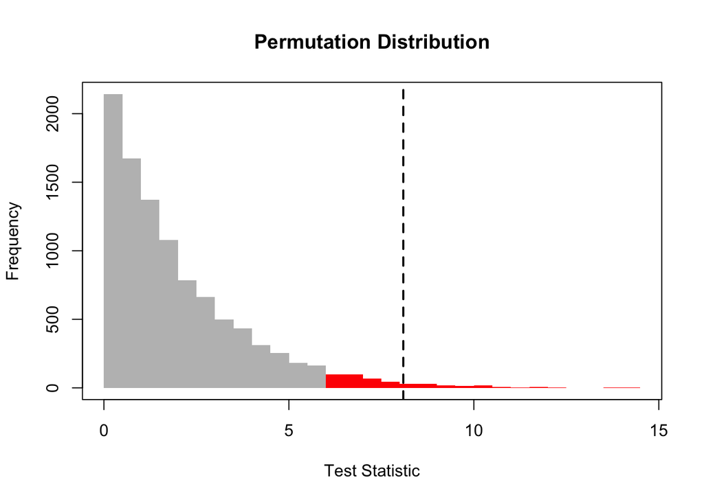

```r
plot(mod)
```

Note: the **nptest** package returns the uncorrected test statistic $H$ (instead of $H^*$).

### 3.3.4 Classic ANOVA Test (stats package)

One-way ANOVA Test using **stats** package:

```r
anova(aov(words ~ group))
```

```
## Analysis of Variance Table
##
## Response: words
##           Df Sum Sq Mean Sq F value   Pr(>F)
## group      2 233.87 116.933  5.8947 0.007513 **
## Residuals 27 535.60  19.837
## ---
## Signif. codes:  0 '***' 0.001 '**' 0.01 '*' 0.05 '.' 0.1 ' ' 1
```

### 3.3.5 Classic ANOVA Test (nptest package)

One-way ANOVA Test using **nptest** package:

```r
library(nptest)
set.seed(1)
mod <- np.aov.test(words, group, median.test = FALSE, var.equal = TRUE)
mod
```

```
##
## One-Way ANOVA Test (Equal Variances)
## Number of Groups: 3
## F = 5.8947,  p-value = 0.0081
```

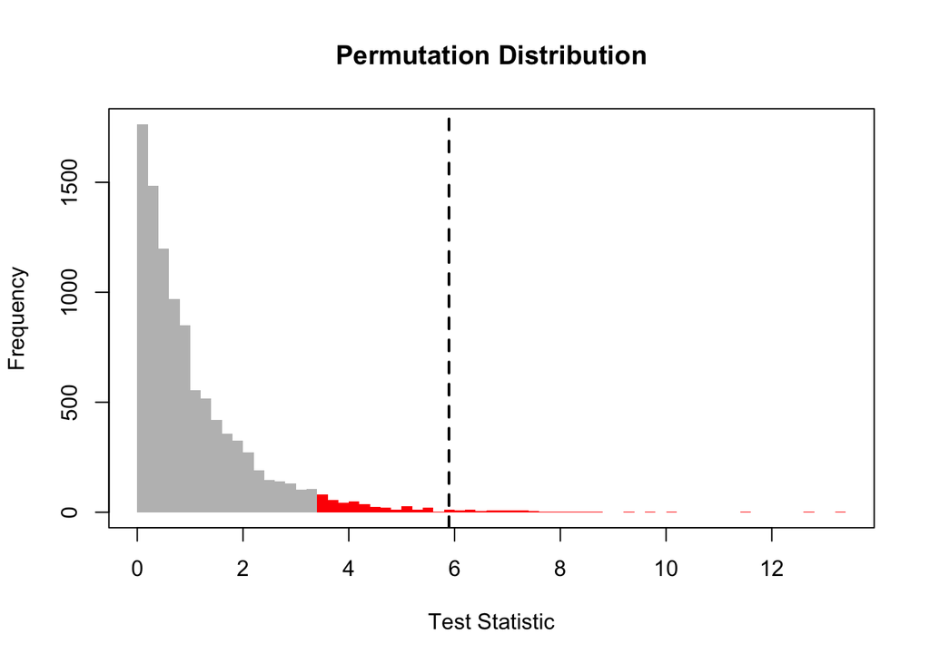

```r
plot(mod)
```